# Còdigo del Trabajo Final

Aprendizaje supervisado y toma de decisiones

Maria del Mar Bibiloni Femenias

En este documento se prentende mostrar todo el código utilizado para realizar el trabajo final de la asignatura *Aprendizaje estadístico y toma de deciciones*.

*No terminado; sólo aparecen algunas notas.*

## Preparación del dataset.

Los datos de mamografías de mujeres con tumores benignos y malignos se pueden descargar del repositiorio UCI, [aquí](http://archive.ics.uci.edu/ml/datasets/Mammographic+Mass).

Cargamos los datos.

```r
original_data= read.table("mammographic_masses.data.txt", sep=",", header=FALSE)
```

Nombramos las columnas.

```r
colnames(original_data) <- c("BIRADS", "Age", "Shape", "Margin", "Density", "Severity")
```

Vemos las primeras filas.

```r
head(original_data,10)
```

| BIRADS | Age | Shape | Margin | Density | Severity |
| --- | --- | --- | --- | --- | --- |
| 5 | 67 | 3 | 5 | 3 | 1 |
| 4 | 43 | 1 | 1 | ? | 1 |
| 5 | 58 | 4 | 5 | 3 | 1 |
| 4 | 28 | 1 | 1 | 3 | 0 |
| 5 | 74 | 1 | 5 | ? | 1 |
| 4 | 65 | 1 | ? | 3 | 0 |
| 4 | 70 | ? | ? | 3 | 0 |
| 5 | 42 | 1 | ? | 3 | 0 |
| 5 | 57 | 1 | 5 | 3 | 1 |
| 5 | 60 | ? | 5 | 1 | 1 |

Dimensiones.

```r
matrix(dim(original_data),nrow=2, ncol=1, dimnames=list(c("Observations: ","Predictors:"), ""))
```

```
##
## Observations:  961
## Predictors:      6
```

Excepto la variable **Age**, las variables son cualitativas. Veamos cuántos valores hay de cada tipo.

```r
apply(original_data[,-2], 2, function(x) table(x))
```

```
## $BIRADS
## x
##   ?   0   2   3   4   5  55   6
##   2   5  14  36 547 345   1  11
##
## $Shape
## x
##   ?   1   2   3   4
##  31 224 211  95 400
##
## $Margin
## x
##   ?   1   2   3   4   5
##  48 357  24 116 280 136
##
## $Density
## x
##   ?   1   2   3   4
##  76  16  59 798  12
##
## $Severity
## x
##   0   1
## 516 445
```

```r
data<-original_data
data=data[-which(original_data$BIRADS==55),]
apply(data[,-2], 2, function(x) table(x))
```

```
## $BIRADS
## x
##   ?   0   2   3   4   5   6
##   2   5  14  36 547 345  11
##
## $Shape
## x
##   ?   1   2   3   4
##  31 224 211  95 399
##
## $Margin
## x
##   ?   1   2   3   4   5
##  48 357  24 115 280 136
##
## $Density
## x
##   ?   1   2   3   4
##  76  16  59 797  12
##
## $Severity
## x
##   0   1
## 516 444
```

Ahora, veamos cuantos NaN tenemos por columna.

```r
data[data=="?"]<- NaN
apply(data, 2, function(x) sum(is.na(x)))
```

```
##   BIRADS      Age    Shape   Margin  Density Severity
##        2        5       31       48       76        0
```

Salvo la edad, no es conveniente cambiar los NaN por algun otro valor. Así, nos quedamos sólo con las observaciones completas.

```r
data <- data[complete.cases(data),]
dim(data)
```

```
## [1] 829   6
```

Tal como sigue, R reconoce las variables como factores, pero para poder aplicar la mayoría de mètodos, necesitamos que sean de tipo numérico.

```r
lapply(data[1,], data.class)
```

```
## $BIRADS
## [1] "factor"
##
## $Age
## [1] "factor"
##
## $Shape
## [1] "factor"
##
## $Margin
## [1] "factor"
##
## $Density
## [1] "factor"
##
## $Severity
## [1] "numeric"
```

Pasamos a numérico, menos la variable Severity.

```r
data <- as.data.frame(apply(data, 2, as.numeric))
data$Severity <- as.factor(data$Severity)
```

### Train-Test

Tomamos 2/3 de los datos aleatoriamente y los guardamos como train. La idea es no usar el conjunto restante (test) para entrenar ningún modelo y así evitar el overfitting. De esta manera, se usará para simular el error en *nuevos datos*.

```r
set.seed(1123)
train=sample(nrow(data), size = ceiling(2/3*nrow(data)) )
test=c(1:nrow(data))[-train]
```

En los datos originales hay una buena proporción de casos de tumor benigno y maligno, es decir, no es un problema no balanceado, por tanto, no hay que modificar la muestra.

Aún así, se debe comprobar si se mantiene, aproximadamente, la proporción en *test* y *train*.

```r
matrix(c( table(original_data$Severity)/nrow(original_data),
table(data[train,]$Severity)/length(train),
table(data[test,]$Severity)/length(test) ), nrow=3, ncol=2, byrow = TRUE,
dimnames=list(c("Original set ","Train set", "Test set"), c("Benign (0)","Malign(1)")) )
```

```
##               Benign (0) Malign(1)
## Original set   0.5369407 0.4630593
## Train set      0.5099458 0.4900542
## Test set       0.5253623 0.4746377
```

Se mantiene. Ya tenemos los conjuntos de entrenamiento y validación.

### Pair Plot

En esta sección, vamos a realizar un pair plot de las variables, con el objetivo de ver la relación entre las variables, dos a dos, y conocer un poco más el dataset.

En cada plot indicamos por colores si cada observación pertenece a la classe benigno o maligno. Además, sólo realizamos el plot sobre train (test es sólo para simular el error fuera de la muestra).

Para hacer el plot, Tratamos los datos como cotinuos (menos severity). Así, los puntos quedan dibujados sobre el plano.

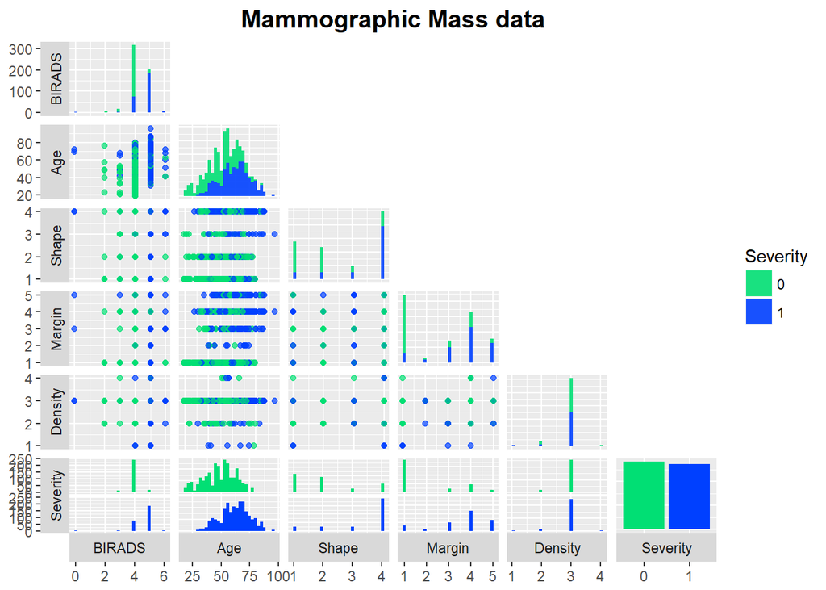

```r
library(ggplot2)
library(GGally)
pairplot <- ggpairs(data[train,],
                    title="Mammographic Mass data",
                    mapping=aes(colour = Severity),
                    upper="blank",
                    lower = list(continuous = wrap("points",alpha = 0.7)),
                    diag = list(continuous = wrap("barDiag", alpha=0.9)),
                    legend = 1,
                    switch = "both")+theme(plot.title=element_text(size = 15,face='bold',
                                                                   hjust=0.5))

for(i in 1:pairplot$nrow) {
  for(j in 1:pairplot$ncol){
    pairplot[i,j] <- pairplot[i,j] +
        scale_fill_manual(values=c("#01DF74", "#0040FF")) +
        scale_color_manual(values=c("#01DF74", "#0040FF"))
  }
}
pairplot
```

### Variables Dummy

Crear dummies:

```r
library("dummies")
data_dum <-dummy.data.frame(data, names=c("BIRADS","Shape", "Margin", "Density"), sep="_")
head(data_dum)
```

| BIRADS_0 | BIRADS_2 | BIRADS_3 | BIRADS_4 | BIRADS_5 | BIRADS_6 | Age | Shape_1 | Shape_2 | Shape_3 | Shape_4 | Margin_1 | Margin_2 | Margin_3 | Margin_4 | Margin_5 | Density_1 | Density_2 | Density_3 | Density_4 | Severity |
| --- | --- | --- | --- | --- | --- | --- | --- | --- | --- | --- | --- | --- | --- | --- | --- | --- | --- | --- | --- | --- |
| 0 | 0 | 0 | 0 | 1 | 0 | 67 | 0 | 0 | 1 | 0 | 0 | 0 | 0 | 0 | 1 | 0 | 0 | 1 | 0 | 1 |
| 0 | 0 | 0 | 0 | 1 | 0 | 58 | 0 | 0 | 0 | 1 | 0 | 0 | 0 | 0 | 1 | 0 | 0 | 1 | 0 | 1 |
| 0 | 0 | 0 | 1 | 0 | 0 | 28 | 1 | 0 | 0 | 0 | 1 | 0 | 0 | 0 | 0 | 0 | 0 | 1 | 0 | 0 |
| 0 | 0 | 0 | 0 | 1 | 0 | 57 | 1 | 0 | 0 | 0 | 0 | 0 | 0 | 0 | 1 | 0 | 0 | 1 | 0 | 1 |
| 0 | 0 | 0 | 0 | 1 | 0 | 76 | 1 | 0 | 0 | 0 | 0 | 0 | 0 | 1 | 0 | 0 | 0 | 1 | 0 | 1 |
| 0 | 0 | 1 | 0 | 0 | 0 | 42 | 0 | 1 | 0 | 0 | 1 | 0 | 0 | 0 | 0 | 0 | 0 | 1 | 0 | 1 |

Quitamos las columnas que seran la categoria referencia.

- BI_RADS: 0, incompleto.
- Shape: 4, más común.
- MArgin: 1, más común.
- Density: 3, bajo. (Además, el más común)

```r
refCategory=names(data_dum) %in% c("BIRADS_0", "Shape_4", "Margin_1", "Density_3")
data_dum = data_dum[, !refCategory]
head(data_dum)
```

| BIRADS_2 | BIRADS_3 | BIRADS_4 | BIRADS_5 | BIRADS_6 | Age | Shape_1 | Shape_2 | Shape_3 | Margin_2 | Margin_3 | Margin_4 | Margin_5 | Density_1 | Density_2 | Density_4 | Severity |
| --- | --- | --- | --- | --- | --- | --- | --- | --- | --- | --- | --- | --- | --- | --- | --- | --- |
| 0 | 0 | 0 | 1 | 0 | 67 | 0 | 0 | 1 | 0 | 0 | 0 | 1 | 0 | 0 | 0 | 1 |
| 0 | 0 | 0 | 1 | 0 | 58 | 0 | 0 | 0 | 0 | 0 | 0 | 1 | 0 | 0 | 0 | 1 |
| 0 | 0 | 1 | 0 | 0 | 28 | 1 | 0 | 0 | 0 | 0 | 0 | 0 | 0 | 0 | 0 | 0 |
| 0 | 0 | 0 | 1 | 0 | 57 | 1 | 0 | 0 | 0 | 0 | 0 | 1 | 0 | 0 | 0 | 1 |
| 0 | 0 | 0 | 1 | 0 | 76 | 1 | 0 | 0 | 0 | 0 | 1 | 0 | 0 | 0 | 0 | 1 |
| 0 | 1 | 0 | 0 | 0 | 42 | 0 | 1 | 0 | 0 | 0 | 0 | 0 | 0 | 0 | 0 | 1 |

## Mètodos de clasificación

Una vez tenemos los datos preparados, vamos a aplicar varios métodos de clasificación para crear diferentes modelos que permitan hacer predicciones sobre futuras mammografias.

### K-nearest neighbors

Para aplicar K-nearest neighbors, necesitamos especificar el número de vecinos (K). Así, usamos validación cruzada en train para elegir la mejor k. (Aquí no usamos las dummies)

```r
library(ISLR)
library(caret)
set.seed(5813)
cross_val <- trainControl(method="cv", number=10)

knn_fit <- train(Severity ~ ., data = data[train,], method = "knn", metric="Accuracy",  trControl = cross_val, tuneLength = 30)
knn_fit
```

```
## k-Nearest Neighbors
##
## 553 samples
##   5 predictor
##   2 classes: '0', '1'
##
## No pre-processing
## Resampling: Cross-Validated (10 fold)
## Summary of sample sizes: 498, 498, 498, 498, 498, 498, ...
## Resampling results across tuning parameters:
##
##   k   Accuracy   Kappa
##    5  0.7884416  0.5770714
##    7  0.7757143  0.5517475
##    9  0.7829545  0.5664661
```

[output cut: 30 more lines]

- knn con k=5 para saber el error en test.

```r
library(class)
library('gmodels')
knn_k5_fit=knn(data[train,], data[test,], cl=data[train,]$Severity, k = 5)
ct_knn=CrossTable(x=data[test,]$Severity, y=knn_k5_fit)
```

```
##
##
##    Cell Contents
## |-------------------------|
## |                       N |
## | Chi-square contribution |
## |           N / Row Total |
## |           N / Col Total |
## |         N / Table Total |
## |-------------------------|
##
##
## Total Observations in Table:  276
##
##
##                       | knn_k5_fit
## data[test, ]$Severity |         0 |         1 | Row Total |
## ----------------------|-----------|-----------|-----------|
##                     0 |       120 |        25 |       145 |
##                       |    40.250 |    35.321 |           |
##                       |     0.828 |     0.172 |     0.525 |
##                       |     0.930 |     0.170 |           |
##                       |     0.435 |     0.091 |           |
## ----------------------|-----------|-----------|-----------|
##                     1 |         9 |       122 |       131 |
##                       |    44.551 |    39.096 |           |
##                       |     0.069 |     0.931 |     0.475 |
##                       |     0.070 |     0.830 |           |
##                       |     0.033 |     0.442 |           |
## ----------------------|-----------|-----------|-----------|
##          Column Total |       129 |       147 |       276 |
##                       |     0.467 |     0.533 |           |
## ----------------------|-----------|-----------|-----------|
##
##
```

Si nos fijamos en los tumores clasificados correctamente, el error es pequeño para tipo. En otras palabras, no se equivoca mucho en uno de los casos.

```r
error_knn5 = (ct_knn$t[2] + ct_knn$t[3])/length(test)
accuracy_knn5=1-error_knn5

accuracy_bening_knn5=(ct_knn$t[1])/(ct_knn$t[1] + ct_knn$t[3])
accuracy_malign_knn5=(ct_knn$t[4])/(ct_knn$t[2] + ct_knn$t[4])
```

```r
list_knn5=c(error_knn5, accuracy_knn5, accuracy_bening_knn5,accuracy_malign_knn5)

matrix(list_knn5, nrow=1, ncol=4,
dimnames=list(c("Knn (K=5)"),c("Error", "Accuracy", "Accuracy_bening", "Accuracy_malign")) )
```

```
##               Error  Accuracy Accuracy_bening Accuracy_malign
## Knn (K=5) 0.1231884 0.8768116       0.8275862       0.9312977
```

- knn con k=15 para saber el error en test.

```r
knn_k15_fit=knn(data[train,], data[test,], cl=data[train,]$Severity, k = 15)
ct_knn15=CrossTable(x=data[test,]$Severity, y=knn_k15_fit)
```

```
##
##
##    Cell Contents
## |-------------------------|
## |                       N |
## | Chi-square contribution |
## |           N / Row Total |
## |           N / Col Total |
## |         N / Table Total |
## |-------------------------|
##
##
## Total Observations in Table:  276
##
##
##                       | knn_k15_fit
## data[test, ]$Severity |         0 |         1 | Row Total |
## ----------------------|-----------|-----------|-----------|
##                     0 |       107 |        38 |       145 |
##                       |    35.917 |    25.655 |           |
##                       |     0.738 |     0.262 |     0.525 |
##                       |     0.930 |     0.236 |           |
##                       |     0.388 |     0.138 |           |
## ----------------------|-----------|-----------|-----------|
##                     1 |         8 |       123 |       131 |
##                       |    39.756 |    28.397 |           |
##                       |     0.061 |     0.939 |     0.475 |
##                       |     0.070 |     0.764 |           |
##                       |     0.029 |     0.446 |           |
## ----------------------|-----------|-----------|-----------|
##          Column Total |       115 |       161 |       276 |
##                       |     0.417 |     0.583 |           |
## ----------------------|-----------|-----------|-----------|
##
##
```

```r
error_knn15 = (ct_knn15$t[2] + ct_knn15$t[3])/length(test)
accuracy_knn15=1-error_knn15

accuracy_bening_knn15=(ct_knn15$t[1])/(ct_knn15$t[1] + ct_knn15$t[3])
accuracy_malign_knn15=(ct_knn15$t[4])/(ct_knn15$t[2] + ct_knn15$t[4])

list_knn15=c(error_knn15, accuracy_knn15, accuracy_bening_knn15,accuracy_malign_knn15)

matrix(c(list_knn5,list_knn15), nrow=2, ncol=4, byrow = TRUE,
dimnames=list(c("Knn (K=5)","Knn (K=15)"),c("Error", "Accuracy", "Accuracy_bening", "Accuracy_malign")) )
```

```
##                Error  Accuracy Accuracy_bening Accuracy_malign
## Knn (K=5)  0.1231884 0.8768116       0.8275862       0.9312977
## Knn (K=15) 0.1666667 0.8333333       0.7379310       0.9389313
```

Nos quedamos con k=5!

### Logistic regression

Estimaremos el modelo con todas las variables dummies.

```r
logReg <- glm(Severity ~.,family=binomial(link='logit'),data=data_dum[train,])
logReg$coefficients
```

```
## (Intercept)    BIRADS_2    BIRADS_3    BIRADS_4    BIRADS_5    BIRADS_6
##  13.2754979 -31.1917456 -16.2194465 -16.2525416 -13.6925756 -14.3821252
##         Age     Shape_1     Shape_2     Shape_3    Margin_2    Margin_3
##   0.0382754  -1.0455558  -1.1071628  -0.2152186   1.4908582   0.5366398
##    Margin_4    Margin_5   Density_1   Density_2   Density_4
##   0.8978827   0.6453774   2.3682198  -0.2849035  -1.6998194
```

Error en test.

```r
logReg_fit_0 <- predict(logReg,newdata=data_dum[test,-17], type='response')

#>0.5 --> 1; <0.5 --> 0
logReg_fit_0  <- ifelse(logReg_fit_0  >= 0.5,1,0)

error_logReg_0 <- mean(logReg_fit_0   != data_dum[test,]$Severity)
accuracy_logReg_0=1-error_logReg_0
```

```r
ct_logReg_0=CrossTable(x=data[test,]$Severity, y=logReg_fit_0)
```

```
##
##
##    Cell Contents
## |-------------------------|
## |                       N |
## | Chi-square contribution |
## |           N / Row Total |
## |           N / Col Total |
## |         N / Table Total |
## |-------------------------|
##
##
## Total Observations in Table:  276
##
##
##                       | logReg_fit_0
## data[test, ]$Severity |         0 |         1 | Row Total |
## ----------------------|-----------|-----------|-----------|
##                     0 |       117 |        28 |       145 |
##                       |    36.811 |    31.837 |           |
##                       |     0.807 |     0.193 |     0.525 |
##                       |     0.914 |     0.189 |           |
##                       |     0.424 |     0.101 |           |
## ----------------------|-----------|-----------|-----------|
##                     1 |        11 |       120 |       131 |
##                       |    40.745 |    35.239 |           |
##                       |     0.084 |     0.916 |     0.475 |
##                       |     0.086 |     0.811 |           |
##                       |     0.040 |     0.435 |           |
## ----------------------|-----------|-----------|-----------|
##          Column Total |       128 |       148 |       276 |
##                       |     0.464 |     0.536 |           |
## ----------------------|-----------|-----------|-----------|
##
##
```

```r
accuracy_bening_logReg_0=(ct_logReg_0$t[1])/(ct_logReg_0$t[1] + ct_logReg_0$t[3])
accuracy_malign_logReg_0= (ct_logReg_0$t[4])/(ct_logReg_0$t[2] + ct_logReg_0$t[4])

list_logReg_0=c(error_logReg_0, accuracy_logReg_0, accuracy_bening_logReg_0,accuracy_malign_logReg_0)

matrix(list_logReg_0, nrow=1, ncol=4,
dimnames=list(c("Tree"),c("Error", "Accuracy", "Accuracy_bening", "Accuracy_malign")) )
```

```
##          Error  Accuracy Accuracy_bening Accuracy_malign
## Tree 0.1413043 0.8586957       0.8068966       0.9160305
```

Contrastes de significación, $\alpha=0.05$.

```r
summary(logReg)
```

```
##
## Call:
## glm(formula = Severity ~ ., family = binomial(link = "logit"),
##     data = data_dum[train, ])
##
## Deviance Residuals:
##      Min        1Q    Median        3Q       Max
## -2.63624  -0.52737  -0.00071   0.42555   2.36933
##
## Coefficients:
##               Estimate Std. Error z value Pr(>|z|)
## (Intercept)   13.27550 1695.75826   0.008 0.993754
## BIRADS_2     -31.19175 1919.46230  -0.016 0.987035
## BIRADS_3     -16.21945 1695.75821  -0.010 0.992369
## BIRADS_4     -16.25254 1695.75809  -0.010 0.992353
## BIRADS_5     -13.69258 1695.75810  -0.008 0.993557
## BIRADS_6     -14.38213 1695.75834  -0.008 0.993233
## Age            0.03828    0.01050   3.644 0.000268 ***
## Shape_1       -1.04556    0.43438  -2.407 0.016083 *
## Shape_2       -1.10716    0.38565  -2.871 0.004093 **
## Shape_3       -0.21522    0.46467  -0.463 0.643246
## Margin_2       1.49086    0.73299   2.034 0.041958 *
## Margin_3       0.53664    0.48269   1.112 0.266239
## Margin_4       0.89788    0.39534   2.271 0.023136 *
## Margin_5       0.64538    0.52310   1.234 0.217298
## Density_1      2.36822    1.28275   1.846 0.064861 .
## Density_2     -0.28490    0.54512  -0.523 0.601223
## Density_4     -1.69982    1.04030  -1.634 0.102266
## ---
## Signif. codes:  0 '***' 0.001 '**' 0.01 '*' 0.05 '.' 0.1 ' ' 1
##
## (Dispersion parameter for binomial family taken to be 1)
##
##     Null deviance: 766.40  on 552  degrees of freedom
## Residual deviance: 418.33  on 536  degrees of freedom
## AIC: 452.33
##
## Number of Fisher Scoring iterations: 15
```

Ningún coeficiente del grupo BI-RADS ni Density es significativo. Matriz de correlaciones.

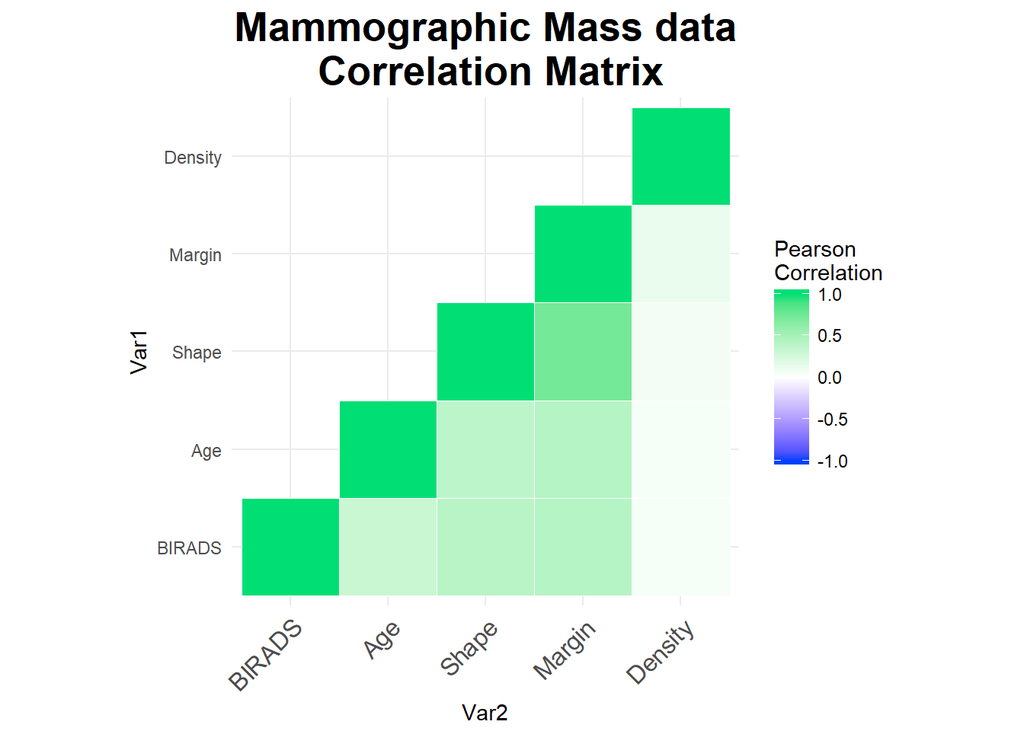

```r
# Melt the correlation matrix

cormat = cor(data[,-6])
get_upper_tri <- function(cormat){
  cormat[lower.tri(cormat)]<- NA
  return(cormat)
}
library(reshape2)
upper_tri <-get_upper_tri(cormat)
melted_cormat <- melt(upper_tri, na.rm = TRUE)
# Heatmap
library(ggplot2)
ggplot(data = melted_cormat, aes(Var2, Var1, fill = value))+
 geom_tile(color = "white")+
 scale_fill_gradient2(low = "#0040FF", high = "#01DF74", mid = "white",
   midpoint = 0, limit = c(-1,1), space = "Lab",
   name="Pearson\nCorrelation") +
  labs(title= "Mammographic Mass data\n Correlation Matrix")+
  theme_minimal()+
 theme(axis.text.x = element_text(angle = 45, vjust = 1,
    size = 12, hjust = 1))+
 coord_fixed()+theme(plot.title=element_text(size = 20,face='bold',hjust=0.5))
```

Density no està muy correlacionada con ninguna otra variable. Eliminamos BI-RADS y repetimos ($\alpha=0.05$).

```r
data_logReg = data_dum[,6:17]
logReg_notBR <- glm(Severity ~.,family=binomial(link='logit'),data=data_logReg[train,])
summary(logReg_notBR)
```

```
##
## Call:
## glm(formula = Severity ~ ., family = binomial(link = "logit"),
##     data = data_logReg[train, ])
##
## Deviance Residuals:
##     Min       1Q   Median       3Q      Max
## -2.3702  -0.5817  -0.2420   0.6986   2.4331
##
## Coefficients:
##              Estimate Std. Error z value Pr(>|z|)
## (Intercept) -3.162936   0.608968  -5.194 2.06e-07 ***
## Age          0.048689   0.009215   5.284 1.26e-07 ***
## Shape_1     -1.303235   0.380165  -3.428 0.000608 ***
## Shape_2     -1.399195   0.340155  -4.113 3.90e-05 ***
## Shape_3     -0.305117   0.398268  -0.766 0.443611
## Margin_2     1.859744   0.664777   2.798 0.005149 **
## Margin_3     1.414485   0.412466   3.429 0.000605 ***
## Margin_4     1.532407   0.348508   4.397 1.10e-05 ***
## Margin_5     1.819720   0.443461   4.103 4.07e-05 ***
## Density_1    2.561736   1.218210   2.103 0.035477 *
## Density_2   -0.122429   0.455143  -0.269 0.787938
## Density_4   -0.805737   0.914925  -0.881 0.378503
## ---
## Signif. codes:  0 '***' 0.001 '**' 0.01 '*' 0.05 '.' 0.1 ' ' 1
##
## (Dispersion parameter for binomial family taken to be 1)
##
##     Null deviance: 766.40  on 552  degrees of freedom
## Residual deviance: 501.97  on 541  degrees of freedom
## AIC: 525.97
##
## Number of Fisher Scoring iterations: 5
```

Ahora si, todos los grupos tienen un coeficiente significativo al 5%.

Coeficientes.

```r
logReg_notBR$coefficients
```

```
## (Intercept)         Age     Shape_1     Shape_2     Shape_3    Margin_2
## -3.16293597  0.04868874 -1.30323502 -1.39919546 -0.30511656  1.85974433
##    Margin_3    Margin_4    Margin_5   Density_1   Density_2   Density_4
##  1.41448458  1.53240731  1.81972038  2.56173594 -0.12242854 -0.80573660
```

Error en test.

```r
logReg_notBR_fit <- predict(logReg_notBR,newdata=data_logReg[test,-12], type='response')

#>0.5 --> 1; <0.5 --> 0
logReg_notBR_fit  <- ifelse(logReg_notBR_fit  >= 0.5,1,0)

error_logReg <- mean(logReg_notBR_fit  != data_logReg[test,]$Severity)
accuracy_logReg = 1-error_logReg
cat('Error',error_logReg)
```

```
## Error 0.1884058
```

```r
cat('Accuracy',accuracy_logReg)
```

```
## Accuracy 0.8115942
```

Veamos el error por classes.

```r
ct_logReg=CrossTable(x=data_logReg[test,]$Severity, y=logReg_notBR_fit)
```

```
##
##
##    Cell Contents
## |-------------------------|
## |                       N |
## | Chi-square contribution |
## |           N / Row Total |
## |           N / Col Total |
## |         N / Table Total |
## |-------------------------|
##
##
## Total Observations in Table:  276
##
##
##                              | logReg_notBR_fit
## data_logReg[test, ]$Severity |         0 |         1 | Row Total |
## -----------------------------|-----------|-----------|-----------|
##                            0 |       101 |        44 |       145 |
##                              |    33.403 |    21.802 |           |
##                              |     0.697 |     0.303 |     0.525 |
##                              |     0.927 |     0.263 |           |
##                              |     0.366 |     0.159 |           |
## -----------------------------|-----------|-----------|-----------|
##                            1 |         8 |       123 |       131 |
##                              |    36.973 |    24.132 |           |
##                              |     0.061 |     0.939 |     0.475 |
##                              |     0.073 |     0.737 |           |
##                              |     0.029 |     0.446 |           |
## -----------------------------|-----------|-----------|-----------|
##                 Column Total |       109 |       167 |       276 |
##                              |     0.395 |     0.605 |           |
## -----------------------------|-----------|-----------|-----------|
##
##
```

Error quitando coeficientes

```r
accuracy_bening_logReg=(ct_logReg$t[1])/(ct_logReg$t[1] + ct_logReg$t[3])
accuracy_malign_logReg= (ct_logReg$t[4])/(ct_logReg$t[2] + ct_logReg$t[4])

list_logReg=c(error_logReg, accuracy_logReg, accuracy_bening_logReg,accuracy_malign_logReg)

matrix(list_logReg, nrow=1, ncol=4,
dimnames=list(c("Tree"),c("Error", "Accuracy", "Accuracy_bening", "Accuracy_malign")) )
```

```
##          Error  Accuracy Accuracy_bening Accuracy_malign
## Tree 0.1884058 0.8115942       0.6965517       0.9389313
```

Hagamos un contraste para saber que modelo explica mejor las variables. * H0: Modelo sin las variables BIRAD-> logReg_notBR * H1: Modelo con todas las variables-> logReg

```r
anova(logReg_notBR, logReg, test="LRT")
```

| Resid. Df | Resid. Dev | Df | Deviance | Pr(>Chi) |
| --- | --- | --- | --- | --- |
| 541 | 501.9734 | NA | NA | NA |
| 536 | 418.3311 | 5 | 83.64226 | 1.449616e-16 |

Rechazamos. El modelo con las variables BIRAD es mejor. Además, comparemos los errores.

```r
matrix(c(list_logReg_0, list_logReg), nrow=2, ncol=4, byrow=TRUE,
dimnames=list(c("Logistic Reg. (All)", "Log Reg. (Not BR)"), c("Error", "Accuracy", "Accuracy_bening", "Accuracy_malign")) )
```

```
##                         Error  Accuracy Accuracy_bening Accuracy_malign
## Logistic Reg. (All) 0.1413043 0.8586957       0.8068966       0.9160305
## Log Reg. (Not BR)   0.1884058 0.8115942       0.6965517       0.9389313
```

**Nota:** No solo buscamos un modelo que reduzca el error de test, sinó uno que reduzca el número de pacientes que se realizan una biopsia innecesária (falsos negativos). Por otra parte, recordemos que tratamos datos de cáncer y, por tanto, no queremos tumores malignos no seleccionados (falsos positivos).

### Árboles de clasificación

Para los árboles de clasificación no es necesario usar las variables dummies.

```r
require(ISLR)
require(tree)
```

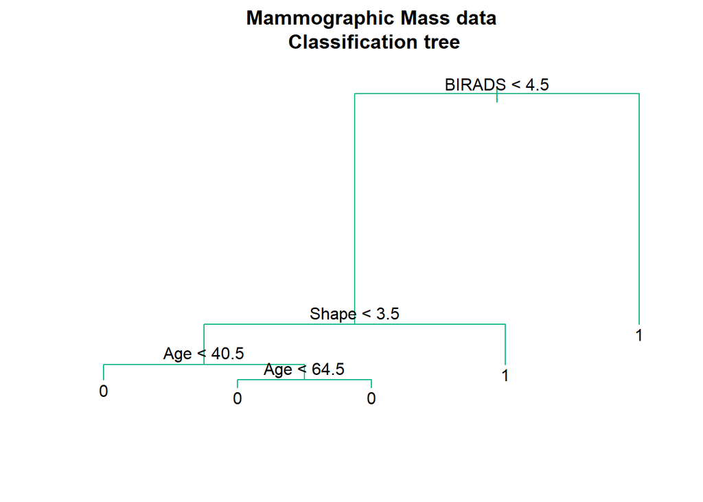

```r
#names(data) <- c("BIRADS",  "Age",      "Shape",    "Margin",   "Density",  "Severity")
tree=tree(Severity ~. ,data=data[train,])
plot(tree, col="#04B486")
title(main = "Mammographic Mass data\n Classification tree\n")
text(tree,pretty=0)
```

Con un árbol de tan poca profundidad, casi no parece necesário hacer validación cruzada para elegir cuando cortar. Aún así, puede haber overfiting al hacer el último paso.

Cabe destacar, que un árbol ayuda a la interpretación. Además en este caso es coherente con la intuición: Si BIRADS es 5, hay una alta sospecha de que sea maligno, por tanto, la biopsia es necesária. En otro caso, hay que analizar los demás resultados para ver si lo és o no, y así evitar un alto número de biopsias innecesarias.

Notemos que no usa Margin ni Density; se basa simplemente en la edad de la mujer y forma del tumor.

Validación cruzada para elegir la profundidad.

```r
set.seed(555)
tree_cv=cv.tree(tree,FUN=prune.misclass, K=10)
tree_cv
```

```
## $size
## [1] 5 3 2 1
##
## $dev
## [1] 106 109 108 271
##
## $k
## [1] -Inf    0    3  170
##
## $method
## [1] "misclass"
##
## attr(,"class")
## [1] "prune"         "tree.sequence"
```

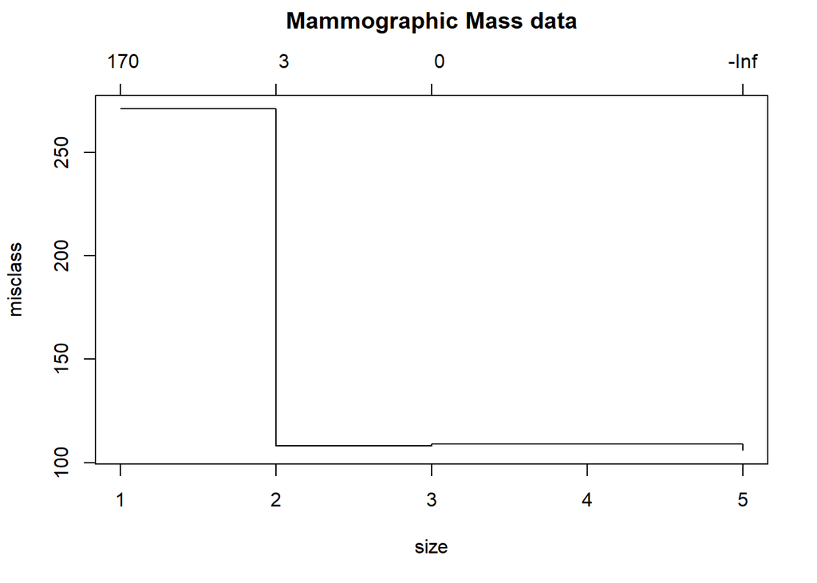

```r
plot(tree_cv)
title(main = "Mammographic Mass data\n \n ")
```

Nos quedamos con 3 de profundidad

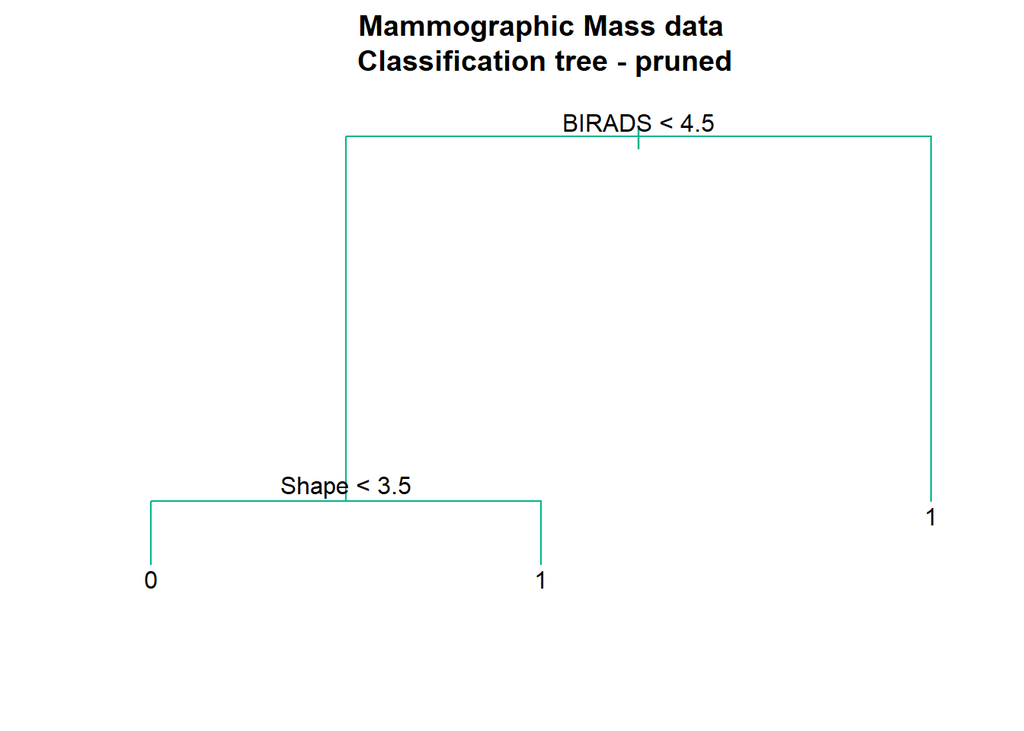

```r
prune_tree=prune.misclass(tree,best=3)
plot(prune_tree, col="#04B486")
title(main = "Mammographic Mass data\n Classification tree - pruned\n")
text(prune_tree,pretty=0)
```

Error.

```r
tree_fit=predict(prune_tree,data[test,],type="class")
ct_tree=with(data[test,],table(tree_fit,Severity))
ct_tree
```

```
##         Severity
## tree_fit   0   1
##        0 115   9
##        1  30 122
```

```r
error_tree=(ct_tree[1,2]+ct_tree[2,1])/length(test)
accuracy_tree=1-error_tree

accuracy_bening_tree=(ct_tree[1,1])/(ct_tree[1,1] + ct_tree[2,1])
accuracy_malign_tree=(ct_tree[2,2])/(ct_tree[1,2] + ct_tree[2,2])

list_tree=c(error_tree, accuracy_tree, accuracy_bening_tree,accuracy_malign_tree)

matrix(list_tree, nrow=1, ncol=4,
dimnames=list(c("Tree (d=3)"),c("Error", "Accuracy", "Accuracy_bening", "Accuracy_malign")) )
```

```
##                Error  Accuracy Accuracy_bening Accuracy_malign
## Tree (d=3) 0.1413043 0.8586957       0.7931034       0.9312977
```

### Random Forests

```r
require(randomForest)
require(MASS)
set.seed(1515)
rForest=randomForest(Severity~.,data=data[train,],ntree=1000)
rForest
```

```
##
## Call:
##  randomForest(formula = Severity ~ ., data = data[train, ], ntree = 1000)
##                Type of random forest: classification
##                      Number of trees: 1000
## No. of variables tried at each split: 2
##
##         OOB estimate of  error rate: 22.06%
## Confusion matrix:
##     0   1 class.error
## 0 227  55   0.1950355
## 1  67 204   0.2472325
```

Notemos que en cada paso toma 2 variables aleatóriamente. Como tenemos el conjunto de test, calculamos el error en lugar de fijar-nos en la estimación de OOB.

Error en test.

```r
rForest_fit=predict(rForest,data[test,])
ct_randForest=with(data[test,],table(rForest_fit,Severity))
ct_randForest
```

```
##            Severity
## rForest_fit   0   1
##           0 120  14
##           1  25 117
```

```r
error_randForest=(ct_randForest[1,2]+ct_randForest[2,1])/length(test)
accuracy_randForest=1-error_randForest

accuracy_bening_randForest=(ct_randForest[1,1])/(ct_randForest[1,1] + ct_randForest[2,1])
accuracy_malign_randForest=(ct_randForest[2,2])/(ct_randForest[1,2] + ct_randForest[2,2])

list_rForest=c(error_randForest, accuracy_randForest, accuracy_bening_randForest,accuracy_malign_randForest)
matrix(list_rForest, nrow=1, ncol=4,
dimnames=list(c("Random Forest (mtry 2)"),c("Error", "Accuracy", "Accuracy_bening", "Accuracy_malign")) )
```

```
##                            Error  Accuracy Accuracy_bening Accuracy_malign
## Random Forest (mtry 2) 0.1413043 0.8586957       0.8275862       0.8931298
```

Ahora, nos podriamos preguntar si tomar 2 variables a cada paso es suficiente o no.

Validación cruzada para escoger mtry.

```r
set.seed(1717)
cross_val_randForest<- trainControl(method="cv", number=10)

df_mtry=as.data.frame(matrix(c(1,2,3,4,5), nrow=5, ncol=1))
names(df_mtry)=c("mtry")

randForest_fit_cv <- train(Severity ~ ., data = data[train,], method = "rf", metric="Accuracy", trControl = cross_val_randForest, tuneGrid = df_mtry )

randForest_fit_cv
```

```
## Random Forest
##
## 553 samples
##   5 predictor
##   2 classes: '0', '1'
##
## No pre-processing
## Resampling: Cross-Validated (10 fold)
## Summary of sample sizes: 498, 498, 498, 497, 497, 498, ...
## Resampling results across tuning parameters:
##
##   mtry  Accuracy   Kappa
##   1     0.8065909  0.6130125
##   2     0.7830195  0.5656897
##   3     0.7758117  0.5513229
##   4     0.7522403  0.5038112
##   5     0.7467208  0.4926691
##
## Accuracy was used to select the optimal model using the largest value.
## The final value used for the model was mtry = 1.
```

```r
randForest_fit_cv$bestTune
```

| mtry |
| --- |
| 1 |

Tomamos mtry=1.

```r
set.seed(1919)
rForest1=randomForest(Severity~.,data=data[train,],ntree=1000, mtry=1)
rForest_fit1=predict(rForest1,data[test,])
ct_randForest1=with(data[test,],table(rForest_fit1,Severity))
ct_randForest1
```

```
##             Severity
## rForest_fit1   0   1
##            0 115   9
##            1  30 122
```

```r
error_randForest1=(ct_randForest1[1,2]+ct_randForest1[2,1])/length(test)
accuracy_randForest1=1-error_randForest1

accuracy_bening_randForest1=(ct_randForest1[1,1])/(ct_randForest1[1,1] + ct_randForest1[2,1])
accuracy_malign_randForest1=(ct_randForest1[2,2])/(ct_randForest1[1,2] + ct_randForest1[2,2])

list_rForest1=c(error_randForest1, accuracy_randForest1, accuracy_bening_randForest1,accuracy_malign_randForest1)
matrix(list_rForest1, nrow=1, ncol=4,
dimnames=list(c("Random Forest (mtry 1)"),c("Error", "Accuracy", "Accuracy_bening", "Accuracy_malign")) )
```

```
##                            Error  Accuracy Accuracy_bening Accuracy_malign
## Random Forest (mtry 1) 0.1413043 0.8586957       0.7931034       0.9312977
```

### Boosting

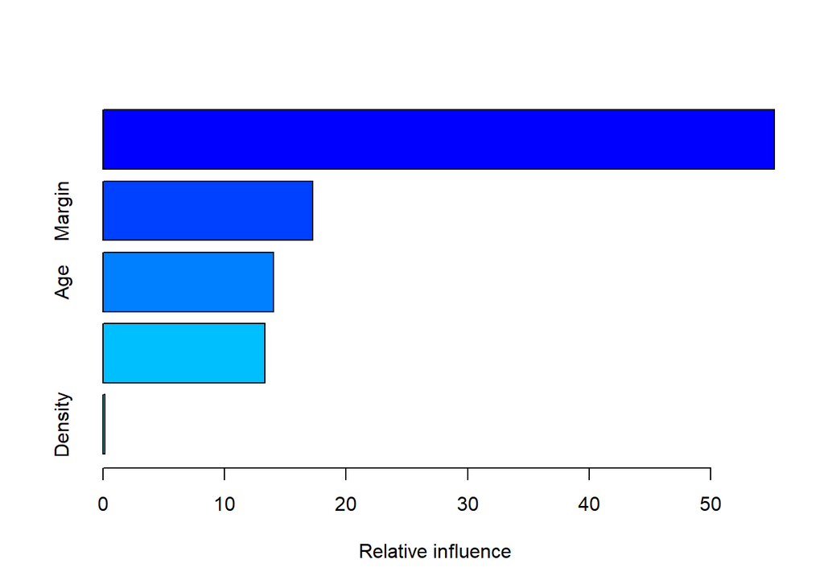

| var | rel.inf |
| --- | --- |
| BIRADS | 55.2222403 |
| Margin | 17.2723455 |
| Age | 14.0382360 |
| Shape | 13.3155735 |
| Density | 0.1516047 |

```r
require(gbm)
#hay problemas con as.factor y gbm
data_gbm=data
data_gbm$Severity = as.character(data_gbm$Severity)

set.seed(1222)
boost = gbm(Severity~. , distribution = "bernoulli", data = data_gbm[train,],
               n.trees = 1000, shrinkage = 0.01)
summary(boost)
```

Error en Test.

```r
boost_pred = predict(object = boost, newdata = data_gbm[test,], n.trees = 1000, type = "response")
#>0.5 --> 1; <0.5 --> 0
boost_pred   <- ifelse(boost_pred  >= 0.5,1,0)

ct_boost=with(data[test,],table(boost_pred,Severity))
ct_boost
```

```
##           Severity
## boost_pred   0   1
##          0 125  14
##          1  20 117
```

```r
error_boost=(ct_boost[1,2]+ct_boost[2,1])/length(test)
accuracy_boost=1-error_boost

accuracy_bening_boost=(ct_boost[1,1])/(ct_boost[1,1] + ct_boost[2,1])
accuracy_malign_boost=(ct_boost[2,2])/(ct_boost[1,2] + ct_boost[2,2])

list_boost=c(error_boost, accuracy_boost, accuracy_bening_boost,accuracy_malign_boost)
matrix(list_boost, nrow=1, ncol=4,
dimnames=list(c("Boosting (shrinkage 0.01)"),c("Error", "Accuracy", "Accuracy_bening", "Accuracy_malign")) )
```

```
##                               Error  Accuracy Accuracy_bening
## Boosting (shrinkage 0.01) 0.1231884 0.8768116        0.862069
##                           Accuracy_malign
## Boosting (shrinkage 0.01)       0.8931298
```

Veamos si podemos mejorar el modelo variando los parámetros.

Validación cruzada.

```r
set.seed(8799)
cross_val_boost <- trainControl(method="cv", number=10)

boost_fit <- train(Severity ~ ., data = data_gbm[train,], method = "gbm", distribution = "bernoulli", metric="Accuracy", trControl = cross_val_boost, tuneLength = 10)
```

```r
boost_fit$bestTune
```

| n.trees | interaction.depth | shrinkage | n.minobsinnode |
| --- | --- | --- | --- |
| 150 | 1 | 0.1 | 10 |

Seleccionamos estos parámetros y calculamos el error en test.

```r
set.seed(3573)
boost = gbm(Severity~. , distribution = "bernoulli", data = data_gbm[train,],
               n.trees = 150, shrinkage = 0.1, interaction.depth = 1, n.minobsinnode = 10)
boost_pred = predict(object = boost, newdata = data_gbm[test,], n.trees = 150, type = "response")
boost_pred   <- ifelse(boost_pred  >= 0.5,1,0)

ct_boost=with(data[test,],table(boost_pred,Severity))
ct_boost
```

```
##           Severity
## boost_pred   0   1
##          0 121  14
##          1  24 117
```

```r
error_boost=(ct_boost[1,2]+ct_boost[2,1])/length(test)
accuracy_boost=1-error_boost

accuracy_bening_boost=(ct_boost[1,1])/(ct_boost[1,1] + ct_boost[2,1])
accuracy_malign_boost=(ct_boost[2,2])/(ct_boost[1,2] + ct_boost[2,2])

list_boost=c(error_boost, accuracy_boost, accuracy_bening_boost,accuracy_malign_boost)
matrix(list_boost, nrow=1, ncol=4,
dimnames=list(c("Boosting (nt=150, d=1, shr=0.1, n.mino=10)"),c("Error", "Accuracy", "Accuracy_bening", "Accuracy_malign")) )
```

```
##                                                Error  Accuracy
## Boosting (nt=150, d=1, shr=0.1, n.mino=10) 0.1376812 0.8623188
##                                            Accuracy_bening Accuracy_malign
## Boosting (nt=150, d=1, shr=0.1, n.mino=10)       0.8344828       0.8931298
```

### Clustering para classificación.

Aunque el clustering es para aprendizaje no supervisado, en este apartado vamos a aplicar el algoritmo kmeans, con k=2, con la idea de ver si los datos se dividen de forma *natural* según Bening/malign.

Para el clustering, escalamos las variables.

Nota: para hacer k-means quitamos la columna Severity; por tanto, no hace falta dividir el conjunto en train o test. Para comparar los modelos, sí que calculamos el error sólo en test.

```r
data_clust=data
data_clust[,-6]=apply(data[,-6], 2, function(x) scale(x))
#data_clust$Age=log(data$Age)

set.seed(2222)
kmeans_sc = kmeans(data_clust[,-6], centers=2)
ct_kmeans=table(kmeans_sc$cluster[test], data_clust[test,]$Severity)
ct_kmeans
```

```
##
##       0   1
##   1 102   6
##   2  43 125
```

```r
#Suponemos 1->0; 2->1

error_kmeans=(ct_kmeans[1,2]+ct_kmeans[2,1])/length(test)
accuracy_kmeans=1-error_kmeans

accuracy_bening_kmeans=(ct_kmeans[1,1])/(ct_kmeans[1,1] + ct_kmeans[2,1])
accuracy_malign_kmeans=(ct_kmeans[2,2])/(ct_kmeans[1,2] + ct_kmeans[2,2])

list_kmeans=c(error_kmeans, accuracy_kmeans, accuracy_bening_kmeans,accuracy_malign_kmeans)
matrix(list_kmeans, nrow=1, ncol=4,
dimnames=list(c("kmeans (scaled)"),c("Error", "Accuracy", "Accuracy_bening", "Accuracy_malign")) )
```

```
##                     Error  Accuracy Accuracy_bening Accuracy_malign
## kmeans (scaled) 0.1775362 0.8224638       0.7034483       0.9541985
```

## Comparación

```r
matrix(c(list_knn5, list_logReg_0, list_logReg, list_tree, list_rForest,
         list_rForest1, list_boost, list_kmeans), nrow=8, ncol=4, byrow=TRUE,
       dimnames=list(c("knn (K=5)","Logistic Reg. (All)", "Log Reg. (Not BR)", "Tree (d=3)",
                       "Random Forest (mtry 2)", "Random Forest (mtry 1)",
                       "Boosting (nt=150, d=1, shr=0.1, n.mino=10)", "kmeans (scaled)"),
                     c("Error", "Accuracy", "Accuracy_bening", "Accuracy_malign")) )
```

```
##                                                Error  Accuracy
## knn (K=5)                                  0.1231884 0.8768116
## Logistic Reg. (All)                        0.1413043 0.8586957
## Log Reg. (Not BR)                          0.1884058 0.8115942
## Tree (d=3)                                 0.1413043 0.8586957
## Random Forest (mtry 2)                     0.1413043 0.8586957
## Random Forest (mtry 1)                     0.1413043 0.8586957
## Boosting (nt=150, d=1, shr=0.1, n.mino=10) 0.1376812 0.8623188
## kmeans (scaled)                            0.1775362 0.8224638
##                                            Accuracy_bening Accuracy_malign
## knn (K=5)                                        0.8275862       0.9312977
## Logistic Reg. (All)                              0.8068966       0.9160305
## Log Reg. (Not BR)                                0.6965517       0.9389313
## Tree (d=3)                                       0.7931034       0.9312977
## Random Forest (mtry 2)                           0.8275862       0.8931298
## Random Forest (mtry 1)                           0.7931034       0.9312977
## Boosting (nt=150, d=1, shr=0.1, n.mino=10)       0.8344828       0.8931298
## kmeans (scaled)                                  0.7034483       0.9541985
```

## Modificación sobre Age

En esta sección tomamos los dos mejores modelos, según nuestros datos, y los aplicamos al dataset con log(data$Age) para reducir su peso.

Los mejores modelos són: knn (K=5) y Boosting (nt=150, d=1, shr=0.1, n.mino=10).

```r
data_logA=data
data_logA$Age=log(data$Age)
```

- knn

Elegir la mejor k con validación cruzada 10-veces.

```r
set.seed(1573)
cross_val_logA <- trainControl(method="cv", number=10)

knn_fit_logA <- train(Severity ~ ., data = data_logA[train,], method = "knn", metric="Accuracy",  trControl = cross_val_logA, tuneLength =30)
knn_fit_logA
```

```
## k-Nearest Neighbors
##
## 553 samples
##   5 predictor
##   2 classes: '0', '1'
##
## No pre-processing
## Resampling: Cross-Validated (10 fold)
## Summary of sample sizes: 498, 497, 498, 497, 498, 498, ...
## Resampling results across tuning parameters:
##
##   k   Accuracy   Kappa
##    5  0.7739935  0.5475880
##    7  0.7883117  0.5762379
##    9  0.7776299  0.5546358
```

[output cut: 30 more lines]

Selecciona K=53; nos quedamo con k=37 (el segundo mejor), ya que k=53 són demasiados vecinos.

```r
knn_fit_logA=knn(data_logA[train,], data_logA[test,], cl=data_logA[train,]$Severity, k = 37)
ct_knn_logA=CrossTable(x=data_logA[test,]$Severity, y=knn_fit_logA)
```

```
##
##
##    Cell Contents
## |-------------------------|
## |                       N |
## | Chi-square contribution |
## |           N / Row Total |
## |           N / Col Total |
## |         N / Table Total |
## |-------------------------|
##
##
## Total Observations in Table:  276
##
##
##                            | knn_fit_logA
## data_logA[test, ]$Severity |         0 |         1 | Row Total |
## ---------------------------|-----------|-----------|-----------|
##                          0 |       135 |        10 |       145 |
##                            |    51.339 |    52.849 |           |
##                            |     0.931 |     0.069 |     0.525 |
##                            |     0.964 |     0.074 |           |
##                            |     0.489 |     0.036 |           |
## ---------------------------|-----------|-----------|-----------|
##                          1 |         5 |       126 |       131 |
##                            |    56.826 |    58.497 |           |
##                            |     0.038 |     0.962 |     0.475 |
##                            |     0.036 |     0.926 |           |
##                            |     0.018 |     0.457 |           |
## ---------------------------|-----------|-----------|-----------|
##               Column Total |       140 |       136 |       276 |
##                            |     0.507 |     0.493 |           |
## ---------------------------|-----------|-----------|-----------|
##
##
```

```r
error_knn_logA = (ct_knn_logA$t[2] + ct_knn_logA$t[3])/length(test)
accuracy_knn_logA=1-error_knn_logA

accuracy_bening_knn_logA=(ct_knn_logA$t[1])/(ct_knn_logA$t[1] + ct_knn_logA$t[3])
accuracy_malign_knn_logA=(ct_knn_logA$t[4])/(ct_knn_logA$t[2] + ct_knn_logA$t[4])

list_knn_logA=c(error_knn_logA, accuracy_knn_logA, accuracy_bening_knn_logA,accuracy_malign_knn_logA)
matrix(list_knn_logA, nrow=1, ncol=4,
dimnames=list(c("Knn (K=37)"),c("Error", "Accuracy", "Accuracy_bening", "Accuracy_malign")) )
```

```
##                 Error  Accuracy Accuracy_bening Accuracy_malign
## Knn (K=37) 0.05434783 0.9456522       0.9310345       0.9618321
```

Los resultados son mucho mejores.

- Boosting

Validación cruzada para seleccionar los parámetros.

```r
data_logA$Severity = as.character(data_logA$Severity)

set.seed(1782)
cross_val_boost_logA <- trainControl(method="cv", number=10)

boost_fit_logA <- train(Severity ~ ., data = data_logA[train,], method = "gbm", metric="Accuracy",  trControl = cross_val_boost_logA, tuneLength = 10)
```

```r
boost_fit_logA$bestTune
```

| n.trees | interaction.depth | shrinkage | n.minobsinnode |
| --- | --- | --- | --- |
| 50 | 2 | 0.1 | 10 |

Seleccionamos estos parámetros y calculamos el error en test.

```r
set.seed(4321)
boost_logA = gbm(Severity~. , distribution = "bernoulli", data = data_logA[train,],
               n.trees =50, shrinkage = 0.1, interaction.depth = 2, n.minobsinnode = 10)
boost_pred_logA = predict(object = boost_logA, newdata = data_logA[test,], n.trees = 50, type = "response")
boost_pred_logA   <- ifelse(boost_pred_logA  >= 0.5,1,0)

ct_boost_logA=with(data_logA[test,],table(boost_pred_logA,Severity))
ct_boost_logA
```

```
##                Severity
## boost_pred_logA   0   1
##               0 126  16
##               1  19 115
```

```r
error_boost_logA=(ct_boost_logA[1,2]+ct_boost_logA[2,1])/length(test)
accuracy_boost_logA=1-error_boost_logA

accuracy_bening_boost_logA=(ct_boost_logA[1,1])/(ct_boost_logA[1,1] + ct_boost_logA[2,1])
accuracy_malign_boost_logA=(ct_boost_logA[2,2])/(ct_boost_logA[1,2] + ct_boost_logA[2,2])

list_boost_logA=c(error_boost_logA, accuracy_boost_logA,
                  accuracy_bening_boost_logA,accuracy_malign_boost_logA)
matrix(list_boost_logA, nrow=1, ncol=4,
dimnames=list(c("Boosting LogAge (nt=50, d=2, shr=0.1, n.mino=10)"),c("Error", "Accuracy", "Accuracy_bening", "Accuracy_malign")) )
```

```
##                                                      Error  Accuracy
## Boosting LogAge (nt=50, d=2, shr=0.1, n.mino=10) 0.1268116 0.8731884
##                                                  Accuracy_bening
## Boosting LogAge (nt=50, d=2, shr=0.1, n.mino=10)       0.8689655
##                                                  Accuracy_malign
## Boosting LogAge (nt=50, d=2, shr=0.1, n.mino=10)       0.8778626
```

En este caso, también se observan mejoras.